# SBC_pollution_China data analysis

## Data source

The data source of this dataset is:

- TFP_SBC_firm

### Variable name

The variables names and labels are the following:

|  | Variables | Labels | Types |
| --- | --- | --- | --- |
| 0 | id | id | object |
| 1 | OWNERSHIP | OWNERSHIP | object |
| 2 | year | year | int64 |
| 3 | geocode4_corr | geocode4_corr | int64 |
| 4 | industry | industry | int64 |
| 5 | occurence | occurence | int64 |
| 6 | tfp_OP | tfp_OP | float64 |
| 7 | tfp_OWNERSHIP | tfp_OWNERSHIP | float64 |
| 8 | polluted_thre | polluted_thre | object |
| 9 | cityen | cityen | object |
| 10 | Coastal | Coastal | bool |
| 11 | TCZ_c | TCZ_c | object |
| 12 | target_c | target_c | float64 |
| 13 | Period | Period | object |
| 14 | FE_c_i | FE_c_i | int64 |
| 15 | FE_t_i | FE_t_i | int64 |
| 16 | FE_t_c | FE_t_c | int64 |
| 17 | FE_c_i_o | FE_c_i_o | int64 |
| 18 | FE_t_o | FE_t_o | int64 |

# Analysis

```
Service account storage and Bigquery are now connected.
Service account storage is stored as <google.cloud.storage.client.Client object at 0xa1c2dce10> and accessible with "Storage_account"
Service account Bigquery is stored as <google.cloud.bigquery.client.Client object at 0xa1c2dc510> and accessible with "bigquery_account"
```

## Load the data

It takes a will to upload the firm data, so we load it localy.

INFO: NumExpr defaulting to 8 threads.

### Load chinese_city_characteristics from Google Spreadsheet

```
(641287, 32)
```

### Compute Herfhindal: proxy Size

$$ H=\sum_{i=1}^{N} s_{i}^{2} $$

where $s_i$ is the market share of industry[city] $i$ in a city [industry], and $N$ is the number of firms.

We proceed as follow:

- Step 1: Compute the share [output, capital, employment] by city-industry: `market_share_cit`
- Step 2: compute the sum of squared market share by industry[city]: `Herfindahl_agg_t`
- Step 3: Compute the average across time: `Herfindahl_agg`
- Step 4: Compute the deciles of step 3: `decile_herfhindal_agg`
  - Low decile implies a low concentration within sectors
  - High decile implies a high concentration within sectors

```
(648797, 19)
```

### Create R tables

```
(648797, 25)
```

|  | id | OWNERSHIP | year | geocode4_corr | industry | occurence | tfp_OP | tfp_OWNERSHIP | polluted_thre | cityen | Coastal | TCZ_c | target_c | Period | FE_c_i | FE_t_i | FE_t_c | FE_c_i_o | FE_t_o | Herfindahl_agg | _merge | decile_herfhindal | mean_herfhindal | third_herfhindal | threshold_herfhindal |
| --- | --- | --- | --- | --- | --- | --- | --- | --- | --- | --- | --- | --- | --- | --- | --- | --- | --- | --- | --- | --- | --- | --- | --- | --- | --- |
| 0 | 196670558 | SOE | 2002 | 4414 | 3329 | 1 | -6.869049 | -6.994576 | Above | Meizhou | True | No_TCZ | 0.02597 | Before | 0 | 0 | 0 | 0 | 0 | 0.11822 | both | 9 | 0 | 0 | 1 |
| 1 | 617924545 | PRIVATE | 2004 | 4414 | 3329 | 6 | -5.985354 | -6.034642 | Above | Meizhou | True | No_TCZ | 0.02597 | Before | 0 | 1 | 1 | 1 | 1 | 0.11822 | both | 9 | 0 | 0 | 1 |
| 2 | 617938939 | SOE | 2003 | 4414 | 3332 | 2 | -4.376090 | -4.466880 | Below | Meizhou | True | No_TCZ | 0.02597 | Before | 1 | 2 | 2 | 2 | 2 | 0.11822 | both | 9 | 0 | 0 | 1 |
| 3 | 617924545 | PRIVATE | 2003 | 4414 | 3332 | 6 | -4.555978 | -4.605596 | Below | Meizhou | True | No_TCZ | 0.02597 | Before | 1 | 2 | 2 | 3 | 3 | 0.11822 | both | 9 | 0 | 0 | 1 |
| 4 | 745544854 | PRIVATE | 2004 | 4414 | 3332 | 1 | -5.408212 | -5.441223 | Below | Meizhou | True | No_TCZ | 0.02597 | Before | 1 | 3 | 1 | 3 | 1 | 0.11822 | both | 9 | 0 | 0 | 1 |

# Table TFP

$$ TFP _{fi k t}=\alpha\left(\text { Period } \times \text { Target }_{i} \times \text { Polluting sectors }_{k} \right)+\nu_{i}+\lambda_{t}+\phi_{k}+\epsilon_{i k t} $$

1. Full sample
2. SOE dominated
3. TCZ vs No TCZ
4. Coastal vs No Coastal
5. Kuznet threshold
   - TCZ: 28795
   - Concentrated: 45396
   - SOE output: 30264
   - SOE Capital: 24867
   - SPE employment: 35190

## Test

For each category, proceed as follow:

1. Without Firm's FE
- Test 1
  - `target * polluted * period *ownership`
  - `target * polluted * period` FOR SOE
  - `target * polluted * period` FOR PRIVATE
  - FE: `cio + ct+ti+to` & `ci+ct+ti`
- Test 2
  - Similar to test 1, but filter `TCZ/No TCZ`
- Test 3
  - `target * period *ownership`
  - `target * period` FOR SOE
  - `target * period` FOR PRIVATE
  - FE: `cio + to+tc` & `c+i+t`
- Test 4
  - Similar to test 3, but filter `TCZ/No TCZ`
1. With Firm's FE
- Identical to `Without Firm's FE` but include `firm` fixed effect

### Without firm's fixed effect

Split

1. TRUE

2. TRUE

```
[1] "TFP subsample - Coastal"
[1] "TFP subsample - TCZ"
[1] "TFP subsample - Herfhindhal"
[1] "TFP subsample - tcz"
[1] "TFP subsample - concentrated"
[1] "TFP subsample - output"
[1] "TFP subsample - capital"
[1] "TFP subsample - employment"
```

[output not shown]

[output cut: 10 more lines]

[output not shown]

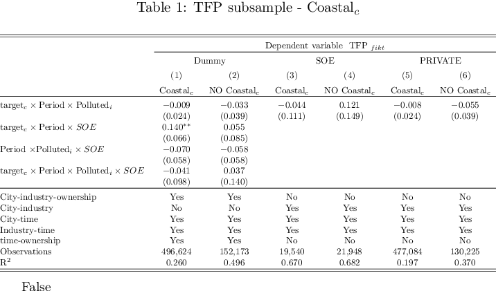

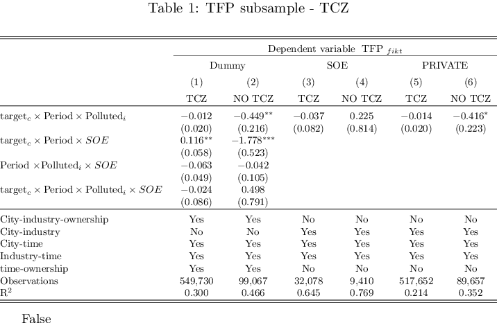

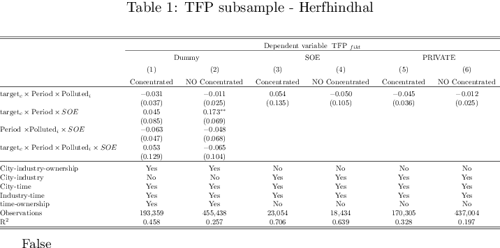

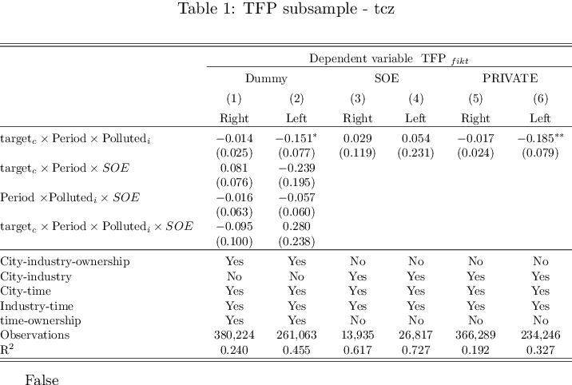

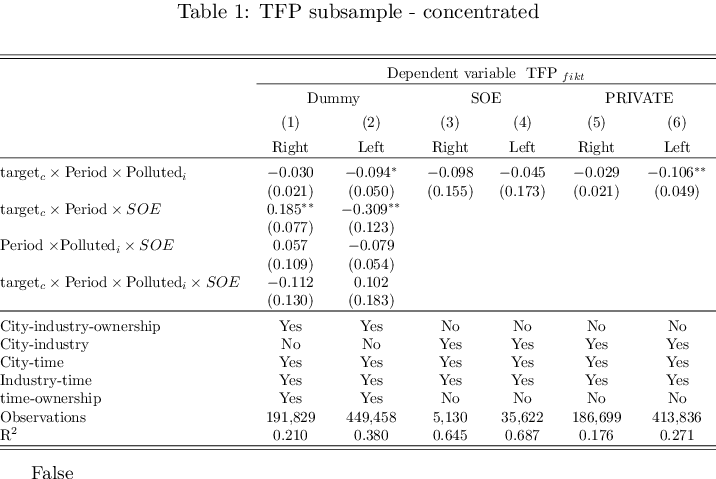

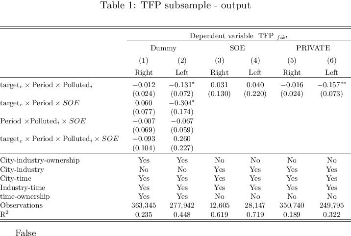

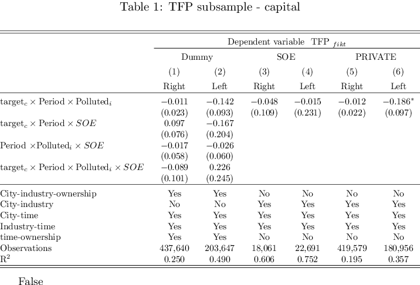

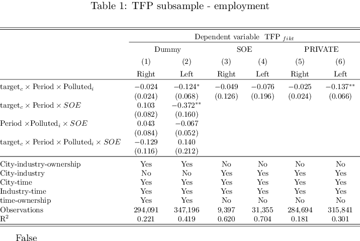

```
[1] "TFP subsample - employment decile 5"
[1] "TFP subsample - employment decile 6"
[1] "TFP subsample - employment decile 7"
[1] "TFP subsample - employment decile 8"
```

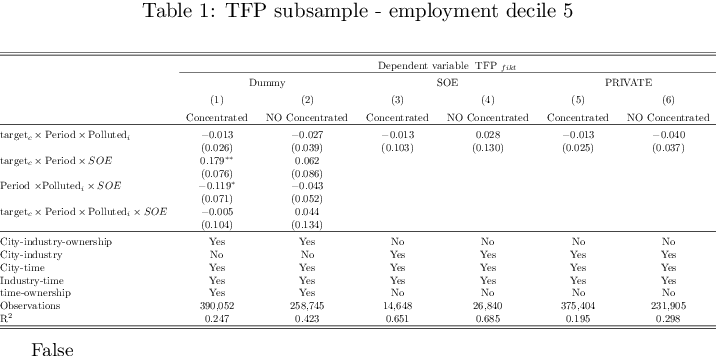

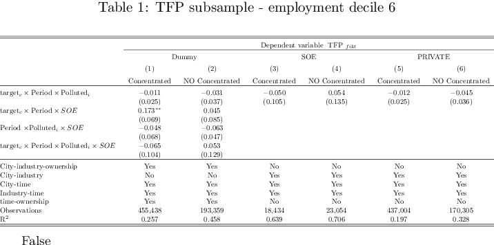

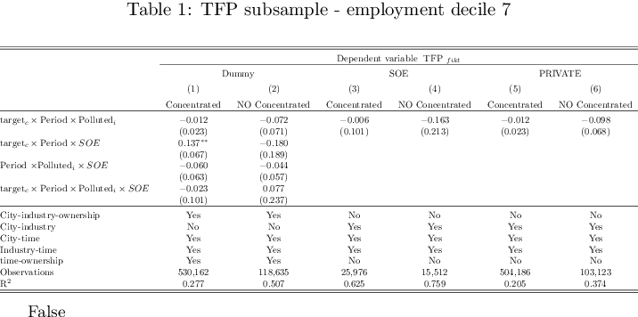

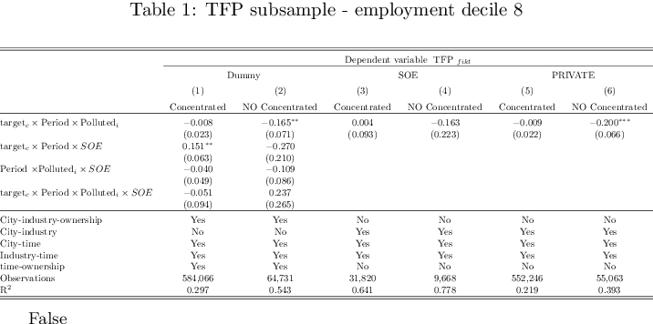

Without polluted

### With firm's fixed effect

Split

1. TRUE

2. TRUE

3. TRUE

4. TRUE

5. TRUE

6. TRUE

7. TRUE

8. TRUE

9. TRUE

10. TRUE

11. TRUE

12. TRUE

```
[1] "TFP subsample - employment decile 5"
[1] "TFP subsample - employment decile 6"
```

```
Tue Apr 21 23:57:32 2020 finished centering model matrix

Wed Apr 22 00:49:24 2020 finished centering model matrix
```

```
[1] "TFP subsample - employment decile 7"
```

```
Wed Apr 22 01:41:09 2020 finished centering model matrix
```

```
[1] "TFP subsample - employment decile 8"
```

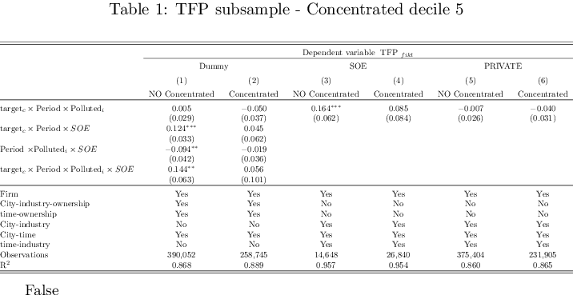

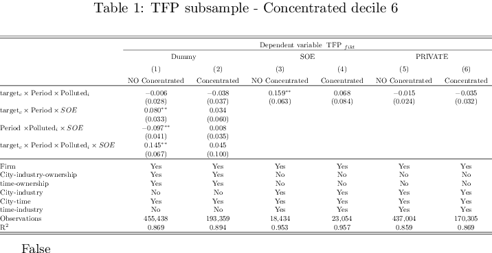

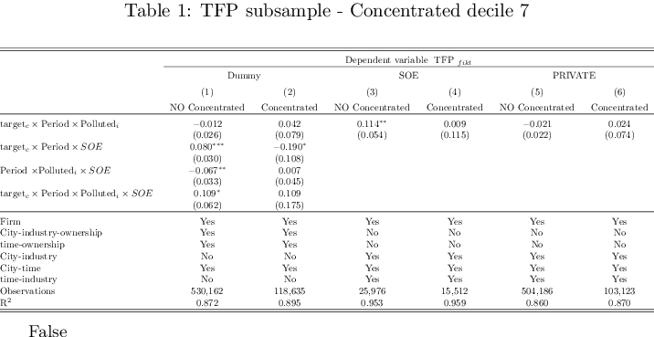

[figure not shown]

Without polluted

# Create reports

```
0
```